# Final Project DS 807: Modeling Unstructured Data

Dagny Wilkins, Drew Rigney, Aleena Linson

## Data Requirements:

- You can pick any type of data that satisfies **at least one** of the following criteria:
  1. Text Data
  2. Image Data
  3. Unsupervised Data
- Some sources are:
  - Kaggle https://www.kaggle.com/datasets
  - UCI Machine Learning Repository https://archive.ics.uci.edu/ml/index.php

Required libraries

```r
library(dplyr)
```

```r
library(ggplot2)
library(ggcorrplot)
library(factoextra)
library(cluster)
library(mclust)
library(keras)
library(mlbench)
library(psych)
library(magrittr)
library(neuralnet)
```

- Read your data in R.

```r
mc=read.table("/Users/aleena/Desktop/MSBA/Ds807/project/marketing_campaign.csv",sep=",",header=TRUE)
head(mc)
```

```
##     ID Year_Birth  Education Marital_Status Income Kidhome Teenhome Dt_Customer
## 1 5524       1957 Graduation         Single  58138       0        0    4/9/2012
## 2 2174       1954 Graduation         Single  46344       1        1    8/3/2014
## 3 4141       1965 Graduation       Together  71613       0        0   8/21/2013
## 4 6182       1984 Graduation       Together  26646       1        0   10/2/2014
## 5 5324       1981        PhD        Married  58293       1        0   1/19/2014
## 6 7446       1967     Master       Together  62513       0        1    9/9/2013
##   Recency MntWines MntFruits MntMeatProducts MntFishProducts MntSweetProducts
## 1      58      635        88             546             172               88
## 2      38       11         1               6               2                1
## 3      26      426        49             127             111               21
## 4      26       11         4              20              10                3
## 5      94      173        43             118              46               27
## 6      16      520        42              98               0               42
##   MntGoldProds NumDealsPurchases NumWebPurchases NumCatalogPurchases
```

[output cut: 20 more lines]

```r
attach(mc)
```

In this section, the team is removing unwanted columns and adding in additional columns. One of the features was the date that a person became a customer. In order to still include this categorical variable, the team calculated the number of days they’ve been a customer and added a new feature called Customer_For. Another column was added called Age to replace the categorical year of birth, so now we have information about the customers’ ages. The team also added a column that calculates how many campaigns the customer accepted. This somewhat captures the five categorical features listing whether a customer accepted or not for the various campaigns.

The columns that won’t be used in this analysis include: ID, Year_Birth, Education, Marital Status, Dt_Customer, AcceptedCmp1, AcceptedCmp2, AcceptedCmp3, AcceptedCmp4, AcceptedCmp5, Complain, Z_CostContract, Z_Revenue, Current_Date, and Response. These columns were either categorical, transformed into numerical format and no longer needed, or weren’t included in the data dictionary and left out for lack of understanding.

After these steps were taken, there are now 18 features in this data set instead of 29.

```r
class(mc$Dt_Customer)
```

```
## [1] "character"
```

```r
mc = mc%>%
  mutate(Dt_Customer = as.Date(Dt_Customer, format = "%m/%d/%Y"))

class(mc$Dt_Customer)
```

```
## [1] "Date"
```

```r
mc$Current_Date = Sys.Date()

mc = mc%>%
   mutate(mc$Current_Date, format = "%m/%d/%Y")

mc$Customer_For = as.numeric(mc$Current_Date - mc$Dt_Customer)
mc$Customer_For
```

[output not shown]

[output cut: 145 more lines]

```r
mc$Accepted_Campaigns = AcceptedCmp1+AcceptedCmp2+AcceptedCmp3+AcceptedCmp4+AcceptedCmp5
mc$Accepted_Campaigns
```

[output not shown]

[output cut: 46 more lines]

```r
head(mc)
```

```
##     ID Year_Birth  Education Marital_Status Income Kidhome Teenhome Dt_Customer
## 1 5524       1957 Graduation         Single  58138       0        0  2012-04-09
## 2 2174       1954 Graduation         Single  46344       1        1  2014-08-03
## 3 4141       1965 Graduation       Together  71613       0        0  2013-08-21
## 4 6182       1984 Graduation       Together  26646       1        0  2014-10-02
## 5 5324       1981        PhD        Married  58293       1        0  2014-01-19
## 6 7446       1967     Master       Together  62513       0        1  2013-09-09
##   Recency MntWines MntFruits MntMeatProducts MntFishProducts MntSweetProducts
## 1      58      635        88             546             172               88
## 2      38       11         1               6               2                1
## 3      26      426        49             127             111               21
## 4      26       11         4              20              10                3
## 5      94      173        43             118              46               27
## 6      16      520        42              98               0               42
##   MntGoldProds NumDealsPurchases NumWebPurchases NumCatalogPurchases
```

[output cut: 27 more lines]

```r
marketing=mc[,-c(1,2,3,4,8,21,22,23,24,25,26,27,28,29,31,32,33)]
head(marketing)
```

```
##   Income Kidhome Teenhome Recency MntWines MntFruits MntMeatProducts
## 1  58138       0        0      58      635        88             546
## 2  46344       1        1      38       11         1               6
## 3  71613       0        0      26      426        49             127
## 4  26646       1        0      26       11         4              20
## 5  58293       1        0      94      173        43             118
## 6  62513       0        1      16      520        42              98
##   MntFishProducts MntSweetProducts MntGoldProds NumDealsPurchases
## 1             172               88           88                 3
## 2               2                1            6                 2
## 3             111               21           42                 1
## 4              10                3            5                 2
## 5              46               27           15                 5
## 6               0               42           14                 2
##   NumWebPurchases NumCatalogPurchases NumStorePurchases NumWebVisitsMonth Age
## 1               8                  10                 4                 7  65
## 2               1                   1                 2                 5  68
## 3               8                   2                10                 4  57
## 4               2                   0                 4                 6  38
## 5               5                   3                 6                 5  41
## 6               6                   4                10                 6  55
##   Customer_For Accepted_Campaigns
## 1         3684                  0
## 2         2838                  0
## 3         3185                  0
## 4         2778                  0
## 5         3034                  0
## 6         3166                  0
```

## The grading rubric can be found below:

|  | R code | Decision/Why | Communication of findings |
| --- | --- | --- | --- |
| Percentage of Assigned Points | 30% | 35% | 35% |

- **Decision/why?**: Explain your reasoning behind your choice of the procedure, set of variables and such for the question.
  - Explain why you use the procedure/model/variables
  - To exceed this criterion, describe steps taken to implement the procedure in a non technical way.
- **Communication of your findings**: Explain your results.
  - Explain why you think one model is better than the other.
  - To exceed this criterion, explain your model in a non technical way.

## Note

- Since there is a great range of potential data, the instructions are written in a general way. If some steps do not make sense in your case, please reach out to verify.

## Part 1: Exploratory Data Analysis (20 points)

1. Explain the purpose of the analysis *for your data*, i.e., what are you trying to achieve?

The purpose of this analysis is to perform clustering in order to understand and summarize customer segments. This will help with marketing efforts.

2. Check for existence of NA’s (missing data)

There are 24 null values present in the Income column. Those rows will be excluded from the analysis since it is a small number of null values.

```r
colSums(is.na(marketing))
```

```
##              Income             Kidhome            Teenhome             Recency
##                  24                   0                   0                   0
##            MntWines           MntFruits     MntMeatProducts     MntFishProducts
##                   0                   0                   0                   0
##    MntSweetProducts        MntGoldProds   NumDealsPurchases     NumWebPurchases
##                   0                   0                   0                   0
## NumCatalogPurchases   NumStorePurchases   NumWebVisitsMonth                 Age
##                   0                   0                   0                   0
##        Customer_For  Accepted_Campaigns
##                   0                   0
```

```r
names(which(colSums(is.na(marketing))>0))
```

```
## [1] "Income"
```

```r
marketing=na.omit(marketing)
```

3. Use appropriate plots for EDA, i.e., word counts for text data.

Box plots were generated for a handful of variables to visually see the distribution. Extreme outliers were removed from the Age and Income features; there were 4 of them. 3 people were older than 100, and one person had an extremely high salary. In the age variable, there were some impossible values. After removing outliers and missing values, there are now 2,212 rows of data.

```r
summary(marketing)
```

```
##      Income          Kidhome          Teenhome         Recency
##  Min.   :  1730   Min.   :0.0000   Min.   :0.0000   Min.   : 0.00
##  1st Qu.: 35303   1st Qu.:0.0000   1st Qu.:0.0000   1st Qu.:24.00
##  Median : 51382   Median :0.0000   Median :0.0000   Median :49.00
##  Mean   : 52247   Mean   :0.4418   Mean   :0.5054   Mean   :49.01
##  3rd Qu.: 68522   3rd Qu.:1.0000   3rd Qu.:1.0000   3rd Qu.:74.00
##  Max.   :666666   Max.   :2.0000   Max.   :2.0000   Max.   :99.00
##     MntWines        MntFruits      MntMeatProducts  MntFishProducts
##  Min.   :   0.0   Min.   :  0.00   Min.   :   0.0   Min.   :  0.00
##  1st Qu.:  24.0   1st Qu.:  2.00   1st Qu.:  16.0   1st Qu.:  3.00
##  Median : 174.5   Median :  8.00   Median :  68.0   Median : 12.00
##  Mean   : 305.1   Mean   : 26.36   Mean   : 167.0   Mean   : 37.64
##  3rd Qu.: 505.0   3rd Qu.: 33.00   3rd Qu.: 232.2   3rd Qu.: 50.00
##  Max.   :1493.0   Max.   :199.00   Max.   :1725.0   Max.   :259.00
##  MntSweetProducts  MntGoldProds    NumDealsPurchases NumWebPurchases
##  Min.   :  0.00   Min.   :  0.00   Min.   : 0.000    Min.   : 0.000
##  1st Qu.:  1.00   1st Qu.:  9.00   1st Qu.: 1.000    1st Qu.: 2.000
##  Median :  8.00   Median : 24.50   Median : 2.000    Median : 4.000
##  Mean   : 27.03   Mean   : 43.97   Mean   : 2.324    Mean   : 4.085
##  3rd Qu.: 33.00   3rd Qu.: 56.00   3rd Qu.: 3.000    3rd Qu.: 6.000
##  Max.   :262.00   Max.   :321.00   Max.   :15.000    Max.   :27.000
##  NumCatalogPurchases NumStorePurchases NumWebVisitsMonth      Age
##  Min.   : 0.000      Min.   : 0.000    Min.   : 0.000    Min.   : 26.00
##  1st Qu.: 0.000      1st Qu.: 3.000    1st Qu.: 3.000    1st Qu.: 45.00
##  Median : 2.000      Median : 5.000    Median : 6.000    Median : 52.00
##  Mean   : 2.671      Mean   : 5.801    Mean   : 5.319    Mean   : 53.18
##  3rd Qu.: 4.000      3rd Qu.: 8.000    3rd Qu.: 7.000    3rd Qu.: 63.00
##  Max.   :28.000      Max.   :13.000    Max.   :20.000    Max.   :129.00
##   Customer_For  Accepted_Campaigns
##  Min.   :2713   Min.   :0.0000
##  1st Qu.:3053   1st Qu.:0.0000
##  Median :3226   Median :0.0000
##  Mean   :3225   Mean   :0.2983
##  3rd Qu.:3399   3rd Qu.:0.0000
##  Max.   :3776   Max.   :4.0000
```

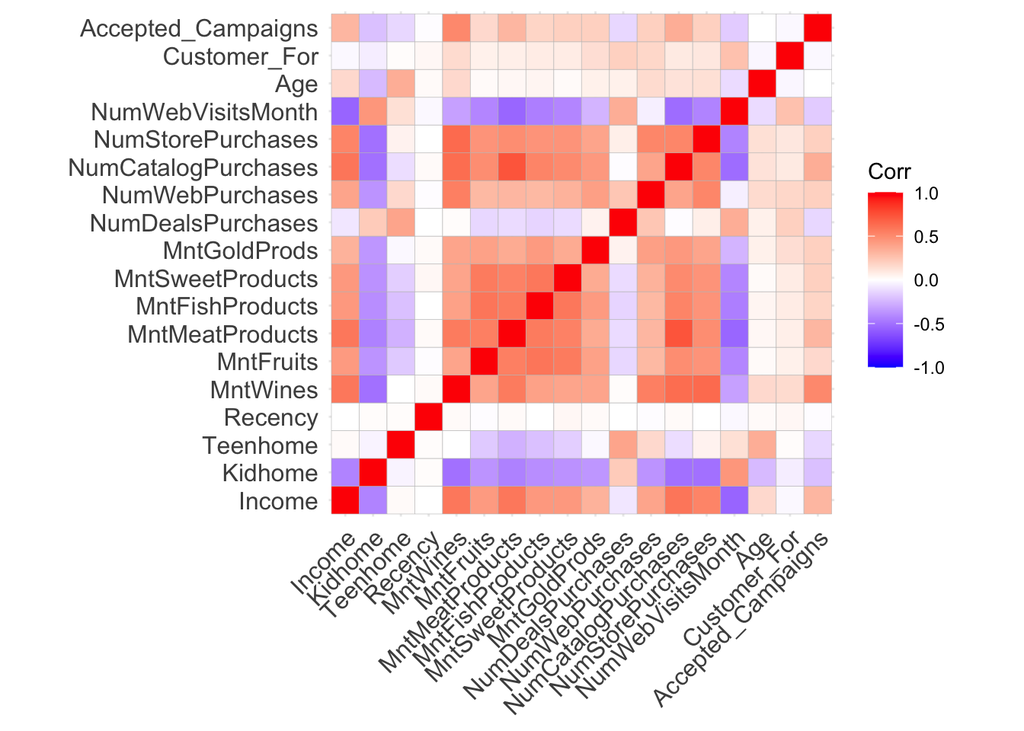

```r
marketing_cor=cor(marketing)
ggcorrplot(marketing_cor)
```

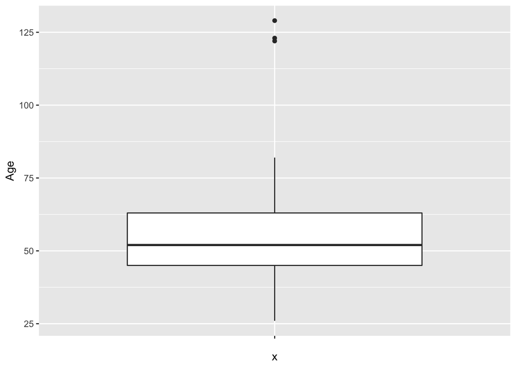

```r
ggplot(data = marketing, aes(x = "", y = Age)) +
  geom_boxplot()
```

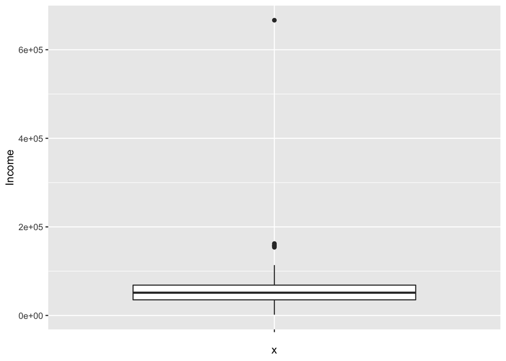

```r
ggplot(data = marketing, aes(x = "", y = Income)) +
  geom_boxplot()
```

```r
#removing age and income outliers
marketing<-marketing[!(marketing$Age>100 | marketing$Income>600000),]
#median is close to 3000 days with a max of about 3900 and minimum of 2700. No new customers

#double checking that age and income outliers were removed
head(marketing)
```

```
##   Income Kidhome Teenhome Recency MntWines MntFruits MntMeatProducts
## 1  58138       0        0      58      635        88             546
## 2  46344       1        1      38       11         1               6
## 3  71613       0        0      26      426        49             127
## 4  26646       1        0      26       11         4              20
## 5  58293       1        0      94      173        43             118
## 6  62513       0        1      16      520        42              98
##   MntFishProducts MntSweetProducts MntGoldProds NumDealsPurchases
## 1             172               88           88                 3
## 2               2                1            6                 2
## 3             111               21           42                 1
## 4              10                3            5                 2
## 5              46               27           15                 5
## 6               0               42           14                 2
##   NumWebPurchases NumCatalogPurchases NumStorePurchases NumWebVisitsMonth Age
## 1               8                  10                 4                 7  65
## 2               1                   1                 2                 5  68
## 3               8                   2                10                 4  57
## 4               2                   0                 4                 6  38
## 5               5                   3                 6                 5  41
## 6               6                   4                10                 6  55
##   Customer_For Accepted_Campaigns
## 1         3684                  0
## 2         2838                  0
## 3         3185                  0
## 4         2778                  0
## 5         3034                  0
## 6         3166                  0
```

```r
dim(marketing)
```

```
## [1] 2212   18
```

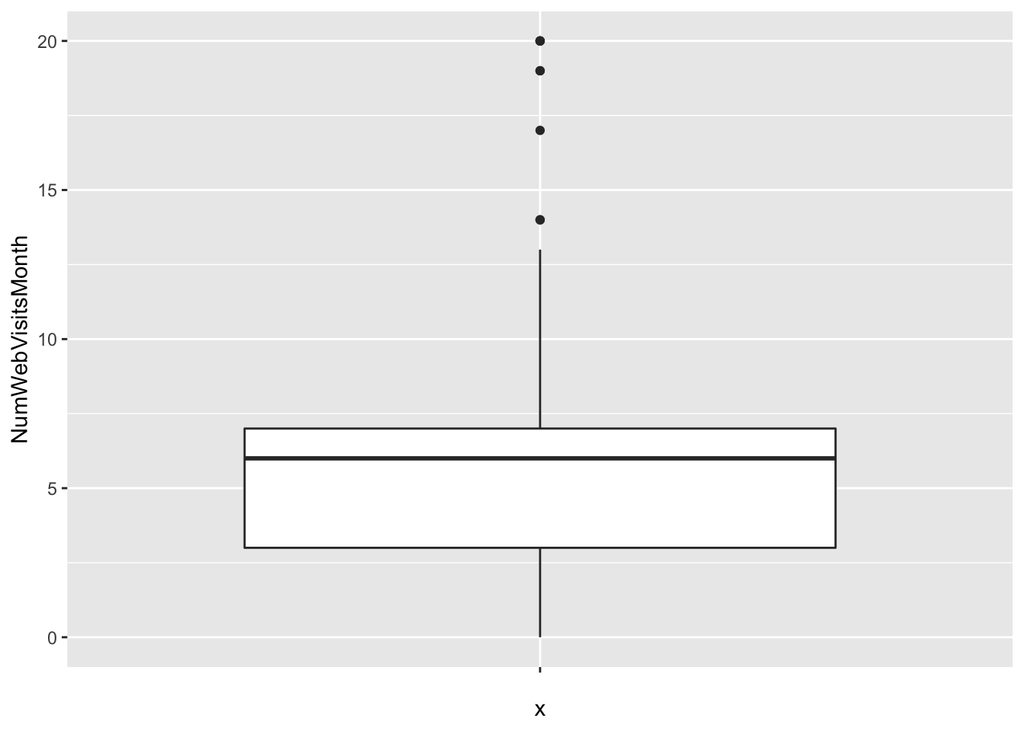

```r
#Boxplots for other numerical variables
ggplot(data = marketing, aes(x = "", y = NumWebVisitsMonth)) +
  geom_boxplot()#Median just over 5, a few outliers near 20
```

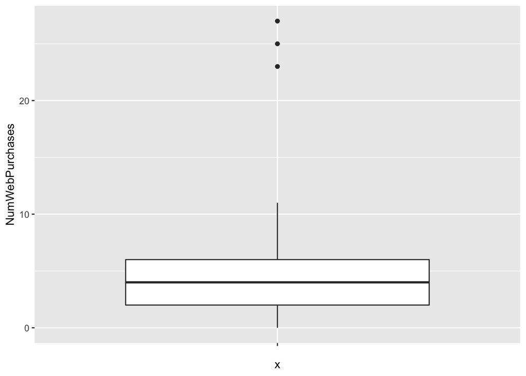

```r
ggplot(data = marketing, aes(x = "", y = NumWebPurchases)) +
  geom_boxplot() #Median less than 5, few outliers above 20
```